# 1st Foray into SQL in R

### 9. Window Functions

```sql
SELECT gender, avg(salary) as Avg_Salary
FROM employee_demographics as dem
JOIN employee_salary as sal
    ON dem.employee_id=sal.employee_id
group by gender;
```

2 records

| gender | Avg_Salary |
| --- | --- |
| Female | 53750.00 |
| Male | 57428.57 |

```sql
SELECT concat(dem.first_name,' ',dem.last_name) AS Name,gender, avg(salary) OVER(partition by gender) As Avg_Salary
FROM employee_demographics as dem
JOIN employee_salary as sal
    ON dem.employee_id=sal.employee_id;
```

Displaying records 1 - 10

| Name | gender | Avg_Salary |
| --- | --- | --- |
| Leslie Knope | Female | 53750.00 |
| April Ludgate | Female | 53750.00 |
| Donna Meagle | Female | 53750.00 |
| Ann Perkins | Female | 53750.00 |
| Tom Haverford | Male | 57428.57 |
| Jerry Gergich | Male | 57428.57 |
| Chris Traeger | Male | 57428.57 |
| Ben Wyatt | Male | 57428.57 |
| Andy Dwyer | Male | 57428.57 |
| Mark Brendanawicz | Male | 57428.57 |

##### 9.1 Rolling Totals

Start at a value and add rows below based on partition

```sql
SELECT concat(dem.first_name,' ',dem.last_name) AS Name,gender,salary, sum(salary) OVER(partition by gender ORDER BY dem.employee_id) As RollingTotal
FROM employee_demographics as dem
JOIN employee_salary as sal
    ON dem.employee_id=sal.employee_id;
```

Displaying records 1 - 10

| Name | gender | salary | RollingTotal |
| --- | --- | --- | --- |
| Leslie Knope | Female | 75000 | 75000 |
| April Ludgate | Female | 25000 | 100000 |
| Donna Meagle | Female | 60000 | 160000 |
| Ann Perkins | Female | 55000 | 215000 |
| Tom Haverford | Male | 50000 | 50000 |
| Jerry Gergich | Male | 50000 | 100000 |
| Chris Traeger | Male | 90000 | 190000 |
| Ben Wyatt | Male | 70000 | 260000 |
| Andy Dwyer | Male | 20000 | 280000 |
| Mark Brendanawicz | Male | 57000 | 337000 |

###### 9.2 Special Window Functions

```sql
SELECT gender, avg(salary) as Avg_Salary
FROM employee_demographics as dem
JOIN employee_salary as sal
    ON dem.employee_id=sal.employee_id
group by gender;
```

2 records

| gender | Avg_Salary |
| --- | --- |
| Female | 53750.00 |
| Male | 57428.57 |

##### 9.3 Ranking Functions

1. **ROW_NUMBER()**: The Strict Counter It assigns a strict, sequential number (1, 2, 3, 4…) to every single row.
   1. Crucial Rule: It NEVER allows ties. If two people make the exact same salary, it will arbitrarily give one a ‘2’ and the other a ‘3’.
2. **RANK()**: The Olympic Medalist It allows ties. If two people have the exact same salary, they get the SAME rank.
   1. Crucial Rule: It SKIPS numbers after a tie.
   2. Example: If there’s a tie for 2nd place, the output is: 1, 2, 2, 4 (it skips 3),
3. **DENSE_RANK()**: The Dense/No-Skip Ranker Like RANK(), it allows ties and gives identical salaries the same rank number.
   1. Crucial Rule: It NEVER skips numbers. It keeps the ranking compact (“dense”).
   2. Example: If there’s a tie for 2nd place, the output is: 1, 2, 2, 3 (next person is 3).

```sql
SELECT  dem.employee_id,concat(dem.first_name,' ',dem.last_name) AS Name,gender,salary,
ROW_NUMBER() OVER(PARTITION BY gender ORDER BY salary DESC) As row_num,
RANK() OVER(PARTITION BY gender ORDER BY salary DESC) As rank_num,
DENSE_RANK() OVER(PARTITION BY gender ORDER BY salary DESC) As dense_rank_num
FROM employee_demographics as dem
JOIN employee_salary as sal
    ON dem.employee_id=sal.employee_id;
```

Displaying records 1 - 10

| employee_id | Name | gender | salary | row_num | rank_num | dense_rank_num |
| --- | --- | --- | --- | --- | --- | --- |
| 1 | Leslie Knope | Female | 75000 | 1 | 1 | 1 |
| 6 | Donna Meagle | Female | 60000 | 2 | 2 | 2 |
| 7 | Ann Perkins | Female | 55000 | 3 | 3 | 3 |
| 4 | April Ludgate | Female | 25000 | 4 | 4 | 4 |
| 8 | Chris Traeger | Male | 90000 | 1 | 1 | 1 |
| 9 | Ben Wyatt | Male | 70000 | 2 | 2 | 2 |
| 12 | Craig Middlebrooks | Male | 65000 | 3 | 3 | 3 |
| 11 | Mark Brendanawicz | Male | 57000 | 4 | 4 | 4 |
| 3 | Tom Haverford | Male | 50000 | 5 | 5 | 5 |
| 5 | Jerry Gergich | Male | 50000 | 6 | 5 | 5 |

### 10. Common Table Expression (CTE)

A temporary, named result set which uses the `WITH` function.

```sql
WITH CTE_Example (Gender, Avg_Sal,Max_Sal,Min_Sal,Count_Sal)As
(
SELECT gender, avg(salary), max(salary),min(salary),count(salary)
from employee_demographics dem
join employee_salary sal
    on dem.employee_id=sal.employee_id
group by gender
)
SELECT *
FROM CTE_Example
;
```

2 records

| Gender | Avg_Sal | Max_Sal | Min_Sal | Count_Sal |
| --- | --- | --- | --- | --- |
| Female | 53750.00 | 75000 | 25000 | 4 |
| Male | 57428.57 | 90000 | 20000 | 7 |

```sql
WITH CTE_Example As
(
SELECT employee_id,gender,birth_date
from employee_demographics
where birth_date > '1985-01-01'
),
CTE_Example2 As
(
select employee_id,salary
from employee_salary
where salary > 50000
)
SELECT *
FROM CTE_Example
JOIN CTE_Example2
    ON CTE_Example.employee_id=CTE_Example2.employee_id
;
```

3 records

| employee_id | gender | birth_date | employee_id | salary |
| --- | --- | --- | --- | --- |
| 7 | Female | 1988-12-01 | 7 | 55000 |
| 9 | Male | 1985-07-26 | 9 | 70000 |
| 12 | Male | 1986-07-27 | 12 | 65000 |

### 11. Stored Procedures

Creating procedures that you run

```sql
select *
from employee_salary;
```

Displaying records 1 - 10

| employee_id | first_name | last_name | occupation | salary | dept_id |
| --- | --- | --- | --- | --- | --- |
| 1 | Leslie | Knope | Deputy Director of Parks and Recreation | 75000 | 1 |
| 2 | Ron | Swanson | Director of Parks and Recreation | 70000 | 1 |
| 3 | Tom | Haverford | Entrepreneur | 50000 | 1 |
| 4 | April | Ludgate | Assistant to the Director of Parks and Recreation | 25000 | 1 |
| 5 | Jerry | Gergich | Office Manager | 50000 | 1 |
| 6 | Donna | Meagle | Office Manager | 60000 | 1 |
| 7 | Ann | Perkins | Nurse | 55000 | 4 |
| 8 | Chris | Traeger | City Manager | 90000 | 3 |
| 9 | Ben | Wyatt | State Auditor | 70000 | 6 |
| 10 | Andy | Dwyer | Shoe Shiner and Musician | 20000 | NA |

#### 11.1 PARAMETERS – Passed as an INPUT into a Stored Procedure

```r
create_proc_sql <- "
CREATE PROCEDURE salary_finder(p_employee_id INT)
BEGIN
    SELECT salary
    FROM employee_salary
    WHERE employee_id = p_employee_id;
END;
"

# Use dbExecute to create the procedure
dbExecute(con, create_proc_sql)
```

```r
# Call the procedure for employee_id = 7
result <- dbExecute(con, "CALL salary_finder(6);")

# View the result
print(result)
```

### 12. Triggers and Events

BLOCK of CODE that automatically executes when an `EVENT` occurs in a table `AFTER` INSERT - after data is added `BEFORE` INSERT - if data is deleted from the table

```sql
SELECT *
from employee_demographics;
```

Displaying records 1 - 10

| employee_id | first_name | last_name | age | gender | birth_date |
| --- | --- | --- | --- | --- | --- |
| 1 | Leslie | Knope | 44 | Female | 1979-09-25 |
| 3 | Tom | Haverford | 36 | Male | 1987-03-04 |
| 4 | April | Ludgate | 29 | Female | 1994-03-27 |
| 5 | Jerry | Gergich | 61 | Male | 1962-08-28 |
| 6 | Donna | Meagle | 46 | Female | 1977-07-30 |
| 7 | Ann | Perkins | 35 | Female | 1988-12-01 |
| 8 | Chris | Traeger | 43 | Male | 1980-11-11 |
| 9 | Ben | Wyatt | 38 | Male | 1985-07-26 |
| 10 | Andy | Dwyer | 34 | Male | 1989-03-25 |
| 11 | Mark | Brendanawicz | 40 | Male | 1983-06-14 |

```sql
SELECT *
from employee_salary;
```

Displaying records 1 - 10

| employee_id | first_name | last_name | occupation | salary | dept_id |
| --- | --- | --- | --- | --- | --- |
| 1 | Leslie | Knope | Deputy Director of Parks and Recreation | 75000 | 1 |
| 2 | Ron | Swanson | Director of Parks and Recreation | 70000 | 1 |
| 3 | Tom | Haverford | Entrepreneur | 50000 | 1 |
| 4 | April | Ludgate | Assistant to the Director of Parks and Recreation | 25000 | 1 |
| 5 | Jerry | Gergich | Office Manager | 50000 | 1 |
| 6 | Donna | Meagle | Office Manager | 60000 | 1 |
| 7 | Ann | Perkins | Nurse | 55000 | 4 |
| 8 | Chris | Traeger | City Manager | 90000 | 3 |
| 9 | Ben | Wyatt | State Auditor | 70000 | 6 |
| 10 | Andy | Dwyer | Shoe Shiner and Musician | 20000 | NA |

##### 12.1 Define the Trigger SQL inside an R multiline string.

```r
dbExecute(con, "DROP TRIGGER IF EXISTS employee_insert;")

trigger_blueprint <- "
CREATE TRIGGER employee_insert
    AFTER INSERT ON employee_salary
    FOR EACH ROW
BEGIN
    INSERT INTO employee_demographics (employee_id, first_name, last_name)
    VALUES (NEW.employee_id, NEW.first_name, NEW.last_name);
END;
"

# ==========================================
# STEP 3: Compile into the Database
# ==========================================
dbExecute(con, trigger_blueprint)
```

```r
# Insert data into the primary table only
dbExecute(con, "
  INSERT INTO employee_salary (employee_id, first_name, last_name, salary)
  VALUES (15, 'Ron', 'Swanson', 80000);
")

# Query the second table to verify the side-effect worked perfectly
side_effect_check <- dbExecute(con, "SELECT * FROM employee_demographics WHERE employee_id = 15;")
print(side_effect_check)
```

### 13. Events

Takes place when SCHEDULED

```r
# 2. Define the Event logic as an R string
event_sql <- "
CREATE EVENT delete_retirees
ON SCHEDULE EVERY 2 SECOND         -- 1. The Clock: Tells the DB how often to wake up
DO
BEGIN                              -- 2. The Task: What happens when it wakes up
    DELETE FROM employee_demographics
    WHERE age >= 60;
END;
"

# 3. Compile the event into the database
dbExecute(con, event_sql)

print("Time-based Event successfully scheduled!")
```

## PROJECT: Data Cleaning

Data Cleaning the *2020-2023 Company Layoffs data* for Analysis

> Step 1: De-duplicate values

> Step 2: Standardize data

> Step 3: Null or Blank values

> Step 4: Remove Any Columns or Rows

```r
dbDisconnect(con)
# 1. Create an in-memory SQLite database connection
con <- dbConnect(RSQLite::SQLite(), ":memory:")
knitr::opts_chunk$set(connection = "con")

# 2. Read your local CSV file into R
layoffs_raw <- read_csv("layoffs.csv")

# 3. Write the data frame into your SQL connection as a table named "layoffs"
dbWriteTable(con, "layoffs", layoffs_raw, overwrite = TRUE)
```

```sql
-- View all records from the initial raw layoffs table
SELECT * FROM layoffs LIMIT 10;
```

Displaying records 1 - 10

| company | location | industry | total_laid_off | percentage_laid_off | date | stage | country | funds_raised_millions |
| --- | --- | --- | --- | --- | --- | --- | --- | --- |
| Atlassian | Sydney | Other | 500 | 0.05 | 3/6/2023 | Post-IPO | Australia | 210 |
| SiriusXM | New York City | Media | 475 | 0.08 | 3/6/2023 | Post-IPO | United States | 525 |
| Alerzo | Ibadan | Retail | 400 | NULL | 3/6/2023 | Series B | Nigeria | 16 |
| UpGrad | Mumbai | Education | 120 | NULL | 3/6/2023 | Unknown | India | 631 |
| Loft | Sao Paulo | Real Estate | 340 | 0.15 | 3/3/2023 | Unknown | Brazil | 788 |
| Embark Trucks | SF Bay Area | Transportation | 230 | 0.7 | 3/3/2023 | Post-IPO | United States | 317 |
| Lendi | Sydney | Real Estate | 100 | NULL | 3/3/2023 | Unknown | Australia | 59 |
| UserTesting | SF Bay Area | Marketing | 63 | NULL | 3/3/2023 | Acquired | United States | 152 |
| Airbnb | SF Bay Area | NA | 30 | NULL | 3/3/2023 | Post-IPO | United States | 6400 |
| Accolade | Seattle | Healthcare | NULL | NULL | 3/3/2023 | Post-IPO | United States | 458 |

### Step 1: Creating a Duplicate Table to preserve raw data

```sql
-- Create and populate the first staging table from the raw data
CREATE TABLE layoffs_staging AS
SELECT * FROM layoffs;
```

```sql
-- Verify the migration
SELECT * FROM layoffs_staging LIMIT 5;
```

5 records

| company | location | industry | total_laid_off | percentage_laid_off | date | stage | country | funds_raised_millions |
| --- | --- | --- | --- | --- | --- | --- | --- | --- |
| Atlassian | Sydney | Other | 500 | 0.05 | 3/6/2023 | Post-IPO | Australia | 210 |
| SiriusXM | New York City | Media | 475 | 0.08 | 3/6/2023 | Post-IPO | United States | 525 |
| Alerzo | Ibadan | Retail | 400 | NULL | 3/6/2023 | Series B | Nigeria | 16 |
| UpGrad | Mumbai | Education | 120 | NULL | 3/6/2023 | Unknown | India | 631 |
| Loft | Sao Paulo | Real Estate | 340 | 0.15 | 3/3/2023 | Unknown | Brazil | 788 |

### Step 2: Check for duplicate values

```sql
WITH duplicate_cte AS (
    SELECT *,
    ROW_NUMBER() OVER(
        PARTITION BY company, location, industry, total_laid_off,
                     percentage_laid_off, date, stage, country, funds_raised_millions
    ) AS row_num
    FROM layoffs_staging
)
SELECT * FROM duplicate_cte
WHERE row_num > 1;
```

5 records

| company | location | industry | total_laid_off | percentage_laid_off | date | stage | country | funds_raised_millions | row_num |
| --- | --- | --- | --- | --- | --- | --- | --- | --- | --- |
| Casper | New York City | Retail | NULL | NULL | 9/14/2021 | Post-IPO | United States | 339 | 2 |
| Cazoo | London | Transportation | 750 | 0.15 | 6/7/2022 | Post-IPO | United Kingdom | 2000 | 2 |
| Hibob | Tel Aviv | HR | 70 | 0.3 | 3/30/2020 | Series A | Israel | 45 | 2 |
| Wildlife Studios | Sao Paulo | Consumer | 300 | 0.2 | 11/28/2022 | Unknown | Brazil | 260 | 2 |
| Yahoo | SF Bay Area | Consumer | 1600 | 0.2 | 2/9/2023 | Acquired | United States | 6 | 2 |

Looking at Casper company

```sql
SELECT *
FROM layoffs_staging
WHERE company = 'Casper';
```

3 records

| company | location | industry | total_laid_off | percentage_laid_off | date | stage | country | funds_raised_millions |
| --- | --- | --- | --- | --- | --- | --- | --- | --- |
| Casper | New York City | Retail | NULL | NULL | 9/14/2021 | Post-IPO | United States | 339 |
| Casper | New York City | Retail | 78 | 0.21 | 4/21/2020 | Post-IPO | United States | 339 |
| Casper | New York City | Retail | NULL | NULL | 9/14/2021 | Post-IPO | United States | 339 |

```sql
SELECT *,
ROW_NUMBER() OVER(
PARTITION BY company,location,industry, total_laid_off, percentage_laid_off, `date`,stage,country,funds_raised_millions) AS ROW_NUM
FROM layoffs_staging;
```

Displaying records 1 - 10

| company | location | industry | total_laid_off | percentage_laid_off | date | stage | country | funds_raised_millions | ROW_NUM |
| --- | --- | --- | --- | --- | --- | --- | --- | --- | --- |
| #Paid | Toronto | Marketing | 19 | 0.17 | 1/27/2023 | Series B | Canada | 21 | 1 |
| &Open | Dublin | Marketing | 9 | 0.09 | 11/17/2022 | Series A | Ireland | 35 | 1 |
| 100 Thieves | Los Angeles | Consumer | 12 | NULL | 7/13/2022 | Series C | United States | 120 | 1 |
| 100 Thieves | Los Angeles | Retail | NULL | NULL | 1/10/2023 | Series C | United States | 120 | 1 |
| 10X Genomics | SF Bay Area | Healthcare | 100 | 0.08 | 8/4/2022 | Post-IPO | United States | 242 | 1 |
| 1stdibs | New York City | Retail | 70 | 0.17 | 4/2/2020 | Series D | United States | 253 | 1 |
| 2TM | Sao Paulo | Crypto | 100 | 0.15 | 9/1/2022 | Unknown | Brazil | 250 | 1 |
| 2TM | Sao Paulo | Crypto | 90 | 0.12 | 6/1/2022 | Unknown | Brazil | 250 | 1 |
| 2U | Washington D.C. | Education | NULL | 0.2 | 7/28/2022 | Post-IPO | United States | 426 | 1 |
| 54gene | Washington D.C. | Healthcare | 95 | 0.3 | 8/29/2022 | Series B | United States | 44 | 1 |

```sql
CREATE TABLE `layoffs_staging2` (
  `company` text,
  `location` text,
  `industry` text,
  `total_laid_off` int DEFAULT NULL,
  `percentage_laid_off` text,
  `date` text,
  `stage` text,
  `country` text,
  `funds_raised_millions` int DEFAULT NULL,
  `row_num` int
);
```

```sql
SELECT *
FROM layoffs_staging2;
```

0 records

| company | location | industry | total_laid_off | percentage_laid_off | date | stage | country | funds_raised_millions | row_num |
| --- | --- | --- | --- | --- | --- | --- | --- | --- | --- |

```sql
INSERT INTO layoffs_staging2
SELECT *,
ROW_NUMBER() OVER(
PARTITION BY company,location,industry, total_laid_off, percentage_laid_off, `date`,stage,country,funds_raised_millions) AS ROW_NUM
FROM layoffs_staging;
```

```sql
SELECT *
FROM layoffs_staging2
WHERE row_num > 1;
```

5 records

| company | location | industry | total_laid_off | percentage_laid_off | date | stage | country | funds_raised_millions | row_num |
| --- | --- | --- | --- | --- | --- | --- | --- | --- | --- |
| Casper | New York City | Retail | NULL | NULL | 9/14/2021 | Post-IPO | United States | 339 | 2 |
| Cazoo | London | Transportation | 750 | 0.15 | 6/7/2022 | Post-IPO | United Kingdom | 2000 | 2 |
| Hibob | Tel Aviv | HR | 70 | 0.3 | 3/30/2020 | Series A | Israel | 45 | 2 |
| Wildlife Studios | Sao Paulo | Consumer | 300 | 0.2 | 11/28/2022 | Unknown | Brazil | 260 | 2 |
| Yahoo | SF Bay Area | Consumer | 1600 | 0.2 | 2/9/2023 | Acquired | United States | 6 | 2 |

```sql
DELETE
FROM layoffs_staging2
WHERE row_num > 1;
```

```sql
SELECT *
FROM layoffs_staging2;
```

Displaying records 1 - 10

| company | location | industry | total_laid_off | percentage_laid_off | date | stage | country | funds_raised_millions | row_num |
| --- | --- | --- | --- | --- | --- | --- | --- | --- | --- |
| #Paid | Toronto | Marketing | 19 | 0.17 | 1/27/2023 | Series B | Canada | 21 | 1 |
| &Open | Dublin | Marketing | 9 | 0.09 | 11/17/2022 | Series A | Ireland | 35 | 1 |
| 100 Thieves | Los Angeles | Consumer | 12 | NULL | 7/13/2022 | Series C | United States | 120 | 1 |
| 100 Thieves | Los Angeles | Retail | 0 | NULL | 1/10/2023 | Series C | United States | 120 | 1 |
| 10X Genomics | SF Bay Area | Healthcare | 100 | 0.08 | 8/4/2022 | Post-IPO | United States | 242 | 1 |
| 1stdibs | New York City | Retail | 70 | 0.17 | 4/2/2020 | Series D | United States | 253 | 1 |
| 2TM | Sao Paulo | Crypto | 100 | 0.15 | 9/1/2022 | Unknown | Brazil | 250 | 1 |
| 2TM | Sao Paulo | Crypto | 90 | 0.12 | 6/1/2022 | Unknown | Brazil | 250 | 1 |
| 2U | Washington D.C. | Education | 0 | 0.2 | 7/28/2022 | Post-IPO | United States | 426 | 1 |
| 54gene | Washington D.C. | Healthcare | 95 | 0.3 | 8/29/2022 | Series B | United States | 44 | 1 |

### Step 3: Standardizing data

```sql
SELECT company, TRIM(company)
FROM layoffs_staging2;
```

Displaying records 1 - 10

| company | TRIM(company) |
| --- | --- |
| #Paid | #Paid |
| &Open | &Open |
| 100 Thieves | 100 Thieves |
| 100 Thieves | 100 Thieves |
| 10X Genomics | 10X Genomics |
| 1stdibs | 1stdibs |
| 2TM | 2TM |
| 2TM | 2TM |
| 2U | 2U |
| 54gene | 54gene |

```sql
UPDATE layoffs_staging2
SET company = TRIM(company);
```

```sql
SELECT *
FROM layoffs_staging2
WHERE industry LIKE 'Crypto%';
```

Displaying records 1 - 10

| company | location | industry | total_laid_off | percentage_laid_off | date | stage | country | funds_raised_millions | row_num |
| --- | --- | --- | --- | --- | --- | --- | --- | --- | --- |
| 2TM | Sao Paulo | Crypto | 100 | 0.15 | 9/1/2022 | Unknown | Brazil | 250 | 1 |
| 2TM | Sao Paulo | Crypto | 90 | 0.12 | 6/1/2022 | Unknown | Brazil | 250 | 1 |
| Abra | SF Bay Area | Crypto | 12 | 0.05 | 6/30/2022 | Series C | United States | 106 | 1 |
| Amber Group | Hong Kong | Crypto | 0 | 0.1 | 9/9/2022 | Series B | Hong Kong | 328 | 1 |
| Autograph | Los Angeles | Crypto | 0 | NULL | 12/16/2022 | Series B | United States | 205 | 1 |
| Bakkt | Atlanta | Crypto | 0 | 0.15 | 12/8/2022 | Post-IPO | United States | 932 | 1 |
| Banxa | Melbourne | Crypto | 70 | 0.3 | 6/27/2022 | Post-IPO | Australia | 13 | 1 |
| BitGo | SF Bay Area | Crypto | 0 | 0.12 | 4/17/2020 | Series B | United States | 69 | 1 |
| BitMEX | Non-U.S. | Crypto | 75 | 0.25 | 4/4/2022 | Seed | Seychelles | 0 | 1 |
| BitMEX | Non-U.S. | Crypto | 0 | 0.3 | 11/2/2022 | Seed | Seychelles | 0 | 1 |

```sql
UPDATE layoffs_staging2
SET industry = 'Crypto'
WHERE industry LIKE 'Crypto%';
```

```sql
SELECT DISTINCT country, TRIM(country, '.')
FROM layoffs_staging2
ORDER BY 1;
```

Displaying records 1 - 10

| country | TRIM(country, ‘.’) |
| --- | --- |
| Argentina | Argentina |
| Australia | Australia |
| Austria | Austria |
| Bahrain | Bahrain |
| Belgium | Belgium |
| Brazil | Brazil |
| Bulgaria | Bulgaria |
| Canada | Canada |
| Chile | Chile |
| China | China |

```sql
UPDATE layoffs_staging2
SET country = RTRIM(country, '.')
WHERE country LIKE 'United States%';
```

```sql
SELECT DISTINCT country, TRIM(country)
FROM layoffs_staging2
ORDER BY 1;
```

Displaying records 1 - 10

| country | TRIM(country) |
| --- | --- |
| Argentina | Argentina |
| Australia | Australia |
| Austria | Austria |
| Bahrain | Bahrain |
| Belgium | Belgium |
| Brazil | Brazil |
| Bulgaria | Bulgaria |
| Canada | Canada |
| Chile | Chile |
| China | China |

### Step 4: Formatting dates

```r
library(dplyr)
library(DBI)

# 1. Pull the data into R
df <- dbGetQuery(con, "SELECT * FROM layoffs_staging2")

# 2. Safely parse dates regardless of input format
if (is.numeric(df$date) || !any(is.na(as.numeric(na.omit(df$date))))) {
  # If dates are Excel-style numeric integers
  df$date <- as.Date(as.numeric(df$date), origin = "1970-01-01")
} else {
  # If dates are strings, try standard formats
  df$date <- as.Date(df$date, tryFormats = c("%Y-%m-%d", "%m/%d/%Y", "%m/%b/%Y", "%Y/%m/%d"))
}

# 3. Drop rows where dates absolutely couldn't be parsed to avoid downstream 'NA' strings
df <- df %>% filter(!is.na(date))

# 4. Convert to character string format 'YYYY-MM-DD' which SQLite expects
df$date <- as.character(df$date)

# 5. Push the cleaned, standardized table back to SQLite
dbWriteTable(con, "layoffs_staging2", df, overwrite = TRUE)
```

```sql
SELECT `date`
FROM layoffs_staging2
LIMIT 10;
```

Displaying records 1 - 10

| date |
| --- |
| 2023-01-27 |
| 2022-11-17 |
| 2022-07-13 |
| 2023-01-10 |
| 2022-08-04 |
| 2020-04-02 |
| 2022-09-01 |
| 2022-06-01 |
| 2022-07-28 |
| 2022-08-29 |

```sql
UPDATE layoffs_staging2
SET company = TRIM(company);
```

```sql
SELECT `date`
FROM layoffs_staging2;
```

Displaying records 1 - 10

| date |
| --- |
| 2023-01-27 |
| 2022-11-17 |
| 2022-07-13 |
| 2023-01-10 |
| 2022-08-04 |
| 2020-04-02 |
| 2022-09-01 |
| 2022-06-01 |
| 2022-07-28 |
| 2022-08-29 |

### Step 5: Dealing with Null or Blanks

```sql
SELECT *
FROM layoffs_staging2
WHERE total_laid_off IS NULL
AND percentage_laid_off IS NULL;
```

0 records

| company | location | industry | total_laid_off | percentage_laid_off | date | stage | country | funds_raised_millions | row_num |
| --- | --- | --- | --- | --- | --- | --- | --- | --- | --- |

```sql
SELECT *
FROM layoffs_staging2
WHERE industry is NULL
OR industry = '';
```

3 records

| company | location | industry | total_laid_off | percentage_laid_off | date | stage | country | funds_raised_millions | row_num |
| --- | --- | --- | --- | --- | --- | --- | --- | --- | --- |
| Airbnb | SF Bay Area | NA | 30 | NULL | 2023-03-03 | Post-IPO | United States | 6400 | 1 |
| Carvana | Phoenix | NA | 2500 | 0.12 | 2022-05-10 | Post-IPO | United States | 1600 | 1 |
| Juul | SF Bay Area | NA | 400 | 0.3 | 2022-11-10 | Unknown | United States | 1500 | 1 |

```sql
SELECT *
FROM layoffs_staging2
WHERE company = '`Ballys Interactive`';
```

0 records

| company | location | industry | total_laid_off | percentage_laid_off | date | stage | country | funds_raised_millions | row_num |
| --- | --- | --- | --- | --- | --- | --- | --- | --- | --- |

#### Step 5.1: FILLING MISSING VALUES in a FIELD based on KNOWN VALUES

4 records

| industry | industry |
| --- | --- |
| NA | Travel |
| NA | Transportation |
| NA | Transportation |
| NA | Consumer |

Displaying records 1 - 10

| company | location | industry | total_laid_off | percentage_laid_off | date | stage | country | funds_raised_millions | row_num |
| --- | --- | --- | --- | --- | --- | --- | --- | --- | --- |
| #Paid | Toronto | Marketing | 19 | 0.17 | 2023-01-27 | Series B | Canada | 21 | 1 |
| &Open | Dublin | Marketing | 9 | 0.09 | 2022-11-17 | Series A | Ireland | 35 | 1 |
| 100 Thieves | Los Angeles | Consumer | 12 | NULL | 2022-07-13 | Series C | United States | 120 | 1 |
| 100 Thieves | Los Angeles | Retail | 0 | NULL | 2023-01-10 | Series C | United States | 120 | 1 |
| 10X Genomics | SF Bay Area | Healthcare | 100 | 0.08 | 2022-08-04 | Post-IPO | United States | 242 | 1 |
| 1stdibs | New York City | Retail | 70 | 0.17 | 2020-04-02 | Series D | United States | 253 | 1 |
| 2TM | Sao Paulo | Crypto | 100 | 0.15 | 2022-09-01 | Unknown | Brazil | 250 | 1 |
| 2TM | Sao Paulo | Crypto | 90 | 0.12 | 2022-06-01 | Unknown | Brazil | 250 | 1 |
| 2U | Washington D.C. | Education | 0 | 0.2 | 2022-07-28 | Post-IPO | United States | 426 | 1 |
| 54gene | Washington D.C. | Healthcare | 95 | 0.3 | 2022-08-29 | Series B | United States | 44 | 1 |

### Step 6: Remove any columns

0 records

| company | location | industry | total_laid_off | percentage_laid_off | date | stage | country | funds_raised_millions | row_num |
| --- | --- | --- | --- | --- | --- | --- | --- | --- | --- |

#### Step 6.1:DROPPING COLUMNS

```sql
ALTER TABLE layoffs_staging2
DROP COLUMN row_num;
```

Displaying records 1 - 10

| company | location | industry | total_laid_off | percentage_laid_off | date | stage | country | funds_raised_millions |
| --- | --- | --- | --- | --- | --- | --- | --- | --- |
| #Paid | Toronto | Marketing | 19 | 0.17 | 2023-01-27 | Series B | Canada | 21 |
| &Open | Dublin | Marketing | 9 | 0.09 | 2022-11-17 | Series A | Ireland | 35 |
| 100 Thieves | Los Angeles | Consumer | 12 | NULL | 2022-07-13 | Series C | United States | 120 |
| 100 Thieves | Los Angeles | Retail | 0 | NULL | 2023-01-10 | Series C | United States | 120 |
| 10X Genomics | SF Bay Area | Healthcare | 100 | 0.08 | 2022-08-04 | Post-IPO | United States | 242 |
| 1stdibs | New York City | Retail | 70 | 0.17 | 2020-04-02 | Series D | United States | 253 |
| 2TM | Sao Paulo | Crypto | 100 | 0.15 | 2022-09-01 | Unknown | Brazil | 250 |
| 2TM | Sao Paulo | Crypto | 90 | 0.12 | 2022-06-01 | Unknown | Brazil | 250 |
| 2U | Washington D.C. | Education | 0 | 0.2 | 2022-07-28 | Post-IPO | United States | 426 |
| 54gene | Washington D.C. | Healthcare | 95 | 0.3 | 2022-08-29 | Series B | United States | 44 |

## Exploratory Data Analysis of Company Layoffs (2020-2023)

```sql
SELECT *
FROM layoffs_staging2;
```

Displaying records 1 - 10

| company | location | industry | total_laid_off | percentage_laid_off | date | stage | country | funds_raised_millions |
| --- | --- | --- | --- | --- | --- | --- | --- | --- |
| #Paid | Toronto | Marketing | 19 | 0.17 | 2023-01-27 | Series B | Canada | 21 |
| &Open | Dublin | Marketing | 9 | 0.09 | 2022-11-17 | Series A | Ireland | 35 |
| 100 Thieves | Los Angeles | Consumer | 12 | NULL | 2022-07-13 | Series C | United States | 120 |
| 100 Thieves | Los Angeles | Retail | 0 | NULL | 2023-01-10 | Series C | United States | 120 |
| 10X Genomics | SF Bay Area | Healthcare | 100 | 0.08 | 2022-08-04 | Post-IPO | United States | 242 |
| 1stdibs | New York City | Retail | 70 | 0.17 | 2020-04-02 | Series D | United States | 253 |
| 2TM | Sao Paulo | Crypto | 100 | 0.15 | 2022-09-01 | Unknown | Brazil | 250 |
| 2TM | Sao Paulo | Crypto | 90 | 0.12 | 2022-06-01 | Unknown | Brazil | 250 |
| 2U | Washington D.C. | Education | 0 | 0.2 | 2022-07-28 | Post-IPO | United States | 426 |
| 54gene | Washington D.C. | Healthcare | 95 | 0.3 | 2022-08-29 | Series B | United States | 44 |

```sql
SELECT MAX(total_laid_off), MAX(percentage_laid_off)
FROM layoffs_staging2;
```

1 records

| MAX(total_laid_off) | MAX(percentage_laid_off) |
| --- | --- |
| 12000 | NULL |

```sql
SELECT company, SUM(total_laid_off)
FROM layoffs_staging2
GROUP BY company
ORDER BY 2 DESC;
```

Displaying records 1 - 10

| company | SUM(total_laid_off) |
| --- | --- |
| Amazon | 18150 |
| Google | 12000 |
| Meta | 11000 |
| Salesforce | 10090 |
| Philips | 10000 |
| Microsoft | 10000 |
| Ericsson | 8500 |
| Uber | 7585 |
| Dell | 6650 |
| Booking.com | 4601 |

```sql
SELECT MIN(`date`), MAX(`date`)
FROM layoffs_staging2;
```

1 records

| MIN(`date`) | MAX(`date`) |
| --- | --- |
| 2020-03-11 | 2023-03-06 |

Displaying records 1 - 10

| country | SUM(total_laid_off) |
| --- | --- |
| United States | 256059 |
| India | 35993 |
| Netherlands | 17220 |
| Sweden | 11264 |
| Brazil | 10391 |
| Germany | 8701 |
| United Kingdom | 6398 |
| Canada | 6319 |
| Singapore | 5995 |
| China | 5905 |

Displaying records 1 - 10

| stage | SUM(total_laid_off) |
| --- | --- |
| Post-IPO | 203632 |
| Unknown | 40716 |
| Acquired | 27576 |
| Series C | 20017 |
| Series D | 19225 |
| Series B | 15311 |
| Series E | 12697 |
| Series F | 9932 |
| Private Equity | 7957 |
| Series H | 7244 |

[output not shown]

### Rolling Totals Analysis

```sql
WITH Rolling_Total AS (
  SELECT
    substr(`date`, 1, 7) AS `MONTH`,
    SUM(total_laid_off) AS Total_LaidOff
  FROM layoffs_staging2
  WHERE substr(`date`, 1, 7) IS NOT NULL
  GROUP BY `MONTH`
)
SELECT
  `MONTH`,
  Total_LaidOff,
  SUM(Total_LaidOff) OVER(ORDER BY `MONTH`) AS Rolling_total
FROM Rolling_Total
ORDER BY `MONTH` ASC;
```

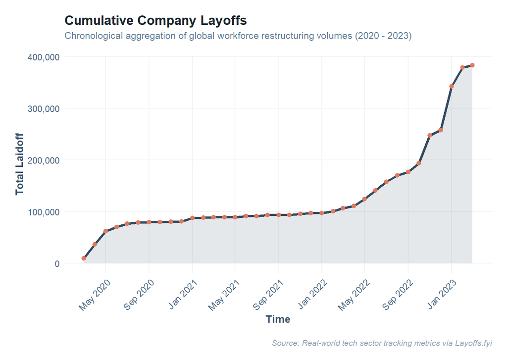

```r
library(dplyr)
library(ggplot2)

# 1. Force Column Headers to Uppercase to prevent casing mismatch errors
colnames(rolling_layoffs) <- toupper(colnames(rolling_layoffs))

# 2. Convert YYYY-MM string paths into a true calendar date sequence
rolling_cleaned <- rolling_layoffs %>%
  filter(!is.na(MONTH), MONTH != "", MONTH != "NA") %>%
  mutate(
    # Appends day "-01" to "YYYY-MM" to enable clean chronologic timeline parsing
    Timeline_Date = as.Date(paste0(MONTH, "-01")),
    ROLLING_TOTAL  = as.numeric(ROLLING_TOTAL)
  ) %>%
  filter(!is.na(Timeline_Date))

# 3. Build the Corporate Portfolio Area-Line Visualization
RollingTotalsPlot <- ggplot(rolling_cleaned, aes(x = Timeline_Date, y = ROLLING_TOTAL)) +
  # Add a subtle, translucent professional canvas gradient shadow
  geom_area(fill = "#4A6572", alpha = 0.15) +
  # Main tracking growth line
  geom_line(color = "#34495E", linewidth = 1.2) +
  # Individual localized data nodes
  geom_point(color = "#E07A5F", size = 1.8) +

  # Format X-axis timeline ticks neatly spaced every 4 months
  scale_x_date(date_labels = "%b %Y", date_breaks = "4 months") +
  # Formats raw large numbers with readable commas (e.g., 150,000)
  scale_y_continuous(labels = scales::label_comma()) +

  labs(
    title = "Cumulative Company Layoffs",
    subtitle = "Chronological aggregation of global workforce restructuring volumes (2020 - 2023)",
    x = "Time",
    y = "Total Laidoff",
    caption = "Source: Real-world tech sector tracking metrics via Layoffs.fyi"
  ) +

  # APPLY SHARED STYLE HERE:
  professional_theme +
  theme(axis.text.x = element_text(angle = 45, hjust = 1)) # Quick date text angle override

# 4. Save a high-fidelity vector copy asset to your local project directory
ggsave(
  filename = "Cumulative Rolling Total of Layoffs between 2020−2023.pdf",
  plot = RollingTotalsPlot,
  width = 10,
  height = 5.5,
  dpi = 300
)

# 5. Output cleanly onto your active notebook HTML markdown canvas
RollingTotalsPlot
```

### Company Layoffs Analysis

```sql
SELECT TRIM(company) As Company, SUM(total_laid_off)
FROM layoffs_staging2
GROUP BY company
ORDER BY 2 DESC;
```

Displaying records 1 - 10

| Company | SUM(total_laid_off) |
| --- | --- |
| Amazon | 18150 |
| Google | 12000 |
| Meta | 11000 |
| Salesforce | 10090 |
| Philips | 10000 |
| Microsoft | 10000 |
| Ericsson | 8500 |
| Uber | 7585 |
| Dell | 6650 |
| Booking.com | 4601 |

```sql
SELECT
  company AS Company,
  strftime('%Y', `date`) AS year_,
  SUM(total_laid_off) AS Total_Laid_Off
FROM layoffs_staging2
WHERE `date` IS NOT NULL
  AND `date` != ''
  AND `date` != 'NA'
GROUP BY company, year_
HAVING year_ IS NOT NULL AND year_ != 'NA'
ORDER BY Total_Laid_Off DESC;
```

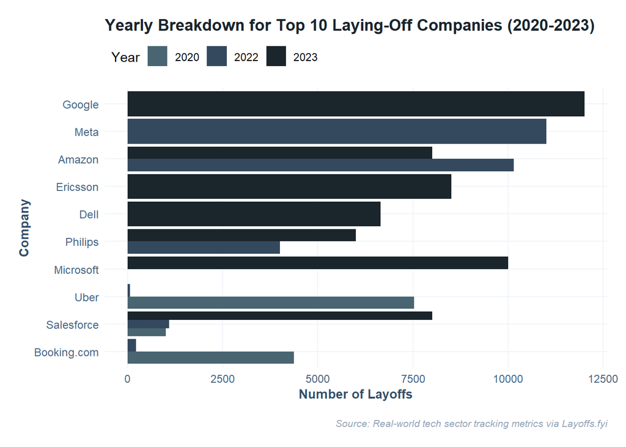

```r
library(dplyr)
library(ggplot2)

# 1. Standardize column names to UPPERCASE
colnames(company_yearly_layoffs) <- toupper(colnames(company_yearly_layoffs))

# 2. Find the top 10 companies using the new UPPERCASE column names
top_10_companies <- company_yearly_layoffs %>%
  group_by(COMPANY) %>%
  summarise(GRAND_TOTAL = sum(TOTAL_LAID_OFF, na.rm = TRUE)) %>%
  slice_max(GRAND_TOTAL, n = 10) %>%
  pull(COMPANY)

# 3. Assign the pipeline outcome right from the start and pipe into ggplot
YearTrendLayoffs <- company_yearly_layoffs %>%
  filter(COMPANY %in% top_10_companies, !is.na(YEAR_)) %>%
  mutate(YEAR_ = as.factor(YEAR_)) %>%
  ggplot(aes(x = reorder(COMPANY, TOTAL_LAID_OFF), y = TOTAL_LAID_OFF, fill = YEAR_)) +
    geom_col(position = "dodge") +
    coord_flip() +
    scale_fill_brewer(palette = "Dark2") +
    labs(
      title = "Yearly Breakdown for Top 10 Laying-Off Companies (2020-2023)",
      x = "Company",
      y = "Number of Layoffs",
      fill = "Year",
      caption = "Source: Real-world tech sector tracking metrics via Layoffs.fyi"
    ) +

    # APPLY SHARED STYLE HERE (Facets look great with the clean white canvas theme):
    scale_fill_manual(values = brand_colors) +
    professional_theme +
    theme(panel.spacing = unit(1.5, "lines")) # Quick layout padding override

# 4. EXPORT THE PLOT IN HIGH QUALITY
ggsave(
  filename = "Yearly Trend of Company Layoffs 2020-2023.pdf",
  plot = YearTrendLayoffs,  # Explicitly tell ggsave which plot object to export
  #width = 10,
  #height = 6,
  #dpi = 300
)

# 5. Print the graph into the Markdown report
YearTrendLayoffs
```

### Layoffs Rankings

Using CAST

```sql
WITH Company_Year AS (
  SELECT
    company AS Company,
    strftime('%Y', `date`) AS Years,
    SUM(total_laid_off) AS Total_Laid_Off
  FROM layoffs_staging2
  WHERE total_laid_off IS NOT NULL
    AND `date` IS NOT NULL
    AND `date` != ''
    AND `date` != 'NA'
  GROUP BY company, Years
),
Company_Year_Rank AS (
  SELECT
    Company,
    Years,
    Total_Laid_Off,
    DENSE_RANK() OVER (PARTITION BY Years ORDER BY Total_Laid_Off DESC) AS Ranking
  FROM Company_Year
  WHERE Years IS NOT NULL
    AND Years != 'NA'
    AND CAST(Years AS INTEGER) >= 2020
)
SELECT Company, Years, Total_Laid_Off, Ranking
FROM Company_Year_Rank
WHERE Ranking <= 5;
```

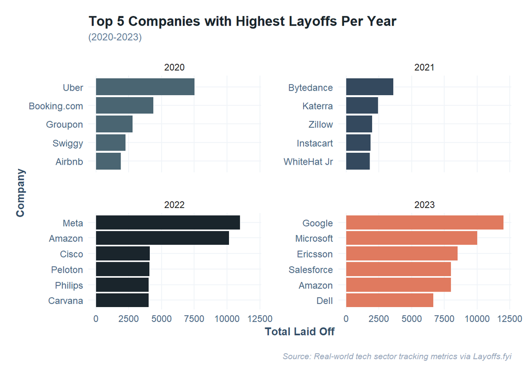

```r
library(ggplot2)
library(dplyr)

# 1. FORCE CASE-INSENSITIVITY: Convert data frame headers to uppercase
colnames(top_5_per_year) <- toupper(colnames(top_5_per_year))

# 2. EMERGENCY SAFETY CHECK: Prevents the knit from breaking if SQL returns 0 rows
if (nrow(top_5_per_year) == 0) {

  plot(0, type='n', axes=FALSE, ann=FALSE)
  text(1, 0, "ERROR: SQL Query returned 0 rows. Check your date formatting.", cex=1.2, col="red")

} else {

# 3. RUN PLOTTING PIPELINE WITH UPDATED UPPERCASE COLUMN NAMES
top5companies_layoffs <- top_5_per_year %>%
  # Filter out empty rows just in case the dataset came back blank
  filter(!is.na(COMPANY), COMPANY != "") %>%

  # Ensure YEARS is treated as a factor so reordering works cleanly
  mutate(YEARS = as.factor(YEARS)) %>%
  mutate(COMPANY = tidytext::reorder_within(COMPANY, TOTAL_LAID_OFF, YEARS)) %>%

  ggplot(aes(x = COMPANY, y = TOTAL_LAID_OFF, fill = YEARS)) +
  geom_col(show.legend = FALSE) +
  tidytext::scale_x_reordered() +
  coord_flip() +
  facet_wrap(~YEARS, scales = "free_y") +

  scale_fill_brewer(palette = "Set2") +

  labs(
    title = "Top 5 Companies with Highest Layoffs Per Year",
    subtitle = "(2020-2023)",
    x = "Company",
    y = "Total Laid Off",
    caption = "Source: Real-world tech sector tracking metrics via Layoffs.fyi"
  ) +

  # APPLY SHARED STYLE HERE (Facets look great with the clean white canvas theme):
    scale_fill_manual(values = brand_colors) +
    professional_theme +
    theme(panel.spacing = unit(1.5, "lines")) # Quick layout padding override

# 3. EXPORT THE PLOT IN HIGH QUALITY
ggsave(
  filename = "Top 5 Companies Layoffs 2020-2023.pdf", # The name of your file
#  width = 10,                            # Width in inches
#  height = 6,                            # Height in inches
#  dpi = 300                              # 300 DPI is standard crisp print quality
)

# 3. Print the graph into the Markdown report
top5companies_layoffs
}
```